# VSTM Notebook

# **VSTM PRE DATA ANALYSIS**

## **Data Prep**

Getting the Data ready for analysis Defaults: R uses dummy coding as it’s default. In this sample, the control group and the simboth condition will be the dummy variables in the analysis. So all Estimates are relative to these dummy variables

### Load Requisite R Packages

note: some of these may not actually be used.

```r
library(ggplot2)
library(lme4)
library(languageR)
library(lmerTest) #give p-values from mixed models
library(influence.ME)
library(plyr) # magic
library(scales) #for making percents on the y-axis of graphs
```

### Read in the dataset (in current directory)

```r
VSTM_data = read.table("VSTM_R_format.csv", header = TRUE, sep = ",")
```

### Omit missing data (e.g. from practice trials)

```r
VSTM_data = na.omit(VSTM_data)
head(VSTM_data, n = 20)
```

```
##    subject session        group      stimtype ACC   RT
## 1        5       1 Experimental ColorPractice   1 3094
## 2        5       1 Experimental ColorPractice   1 1719
## 3        5       1 Experimental ColorPractice   1 1114
## 4        5       1 Experimental ColorPractice   0 1710
## 5        5       1 Experimental     SimColour   1 1086
## 6        5       1 Experimental     SimColour   0 1121
## 7        5       1 Experimental     SimColour   1  909
## 8        5       1 Experimental     SimColour   1  854
## 9        5       1 Experimental     SimColour   1  728
## 10       5       1 Experimental     SimColour   1  935
## 11       5       1 Experimental     SimColour   1  646
## 12       5       1 Experimental     SimColour   1 1289
## 13       5       1 Experimental     SimColour   1  835
## 14       5       1 Experimental     SimColour   0  993
## 15       5       1 Experimental     SimColour   1  999
## 16       5       1 Experimental     SimColour   1  705
## 17       5       1 Experimental     SimColour   1  582
## 18       5       1 Experimental     SimColour   0 1104
## 19       5       1 Experimental     SimColour   1  858
## 20       5       1 Experimental     SimColour   1  859
```

### Omit the Undefined group from the data and specify group as a factor

```r
VSTM_data <- subset(VSTM_data,group=="Control" | group=="Experimental")
VSTM_data$group <- factor(VSTM_data$group)
summary(VSTM_data)
```

```
##     subject         session               group                stimtype
##  Min.   :  5.0   Min.   :1.000   Control     :13609   0            :   1
##  1st Qu.: 45.0   1st Qu.:1.000   Experimental:12089   ColorPractice: 476
##  Median : 98.0   Median :1.000                        PracticeBoth : 476
##  Mean   :104.4   Mean   :1.471                        ShapePractice: 476
##  3rd Qu.:166.0   3rd Qu.:2.000                        SimBoth      :8085
##  Max.   :209.0   Max.   :2.000                        SimColour    :8092
##                                                       SimShape     :8092
##       ACC               RT
##  Min.   :0.0000   Min.   :    0
##  1st Qu.:0.0000   1st Qu.:  999
##  Median :1.0000   Median : 1271
##  Mean   :0.7221   Mean   : 1474
##  3rd Qu.:1.0000   3rd Qu.: 1659
##  Max.   :1.0000   Max.   :27493
##
```

```r
contrasts(VSTM_data$group)
```

```
##              Experimental
## Control                 0
## Experimental            1
```

### Omit the Practice stimtype and specify stimtype as a factor

```r
VSTM_data <- subset(VSTM_data,stimtype=="SimBoth" | stimtype=="SimColour" | stimtype=="SimShape")
VSTM_data$stimtype <- factor(VSTM_data$stimtype)
summary(VSTM_data)
```

```
##     subject         session               group            stimtype
##  Min.   :  5.0   Min.   :1.000   Control     :12852   SimBoth  :8085
##  1st Qu.: 45.0   1st Qu.:1.000   Experimental:11417   SimColour:8092
##  Median : 98.0   Median :1.000                        SimShape :8092
##  Mean   :104.4   Mean   :1.471
##  3rd Qu.:166.0   3rd Qu.:2.000
##  Max.   :209.0   Max.   :2.000
##       ACC               RT
##  Min.   :0.0000   Min.   :    0
##  1st Qu.:0.0000   1st Qu.:  990
##  Median :1.0000   Median : 1256
##  Mean   :0.7206   Mean   : 1453
##  3rd Qu.:1.0000   3rd Qu.: 1642
##  Max.   :1.0000   Max.   :27493
```

```r
contrasts(VSTM_data$stimtype)
```

```
##           SimColour SimShape
## SimBoth           0        0
## SimColour         1        0
## SimShape          0        1
```

### Isolate the session to the first session

```r
VSTM_data_pre <- subset(VSTM_data, session==1)
VSTM_data_pre$session <- factor(VSTM_data_pre$session)
summary(VSTM_data_pre)
```

```
##     subject      session            group           stimtype
##  Min.   :  5.0   1:12845   Control     :6936   SimBoth  :4277
##  1st Qu.: 45.0             Experimental:5909   SimColour:4284
##  Median : 98.0                                 SimShape :4284
##  Mean   :105.5
##  3rd Qu.:172.0
##  Max.   :209.0
##       ACC               RT
##  Min.   :0.0000   Min.   :    0
##  1st Qu.:0.0000   1st Qu.: 1034
##  Median :1.0000   Median : 1303
##  Mean   :0.7194   Mean   : 1508
##  3rd Qu.:1.0000   3rd Qu.: 1698
##  Max.   :1.0000   Max.   :27493
```

### specify subject as a factor

```r
VSTM_data_pre$subject <- as.factor(VSTM_data_pre$subject)

summary(VSTM_data_pre)
```

```
##     subject      session            group           stimtype
##  5      :  204   1:12845   Control     :6936   SimBoth  :4277
##  6      :  204             Experimental:5909   SimColour:4284
##  7      :  204                                 SimShape :4284
##  8      :  204
##  9      :  204
##  10     :  204
##  (Other):11621
##       ACC               RT
##  Min.   :0.0000   Min.   :    0
##  1st Qu.:0.0000   1st Qu.: 1034
##  Median :1.0000   Median : 1303
##  Mean   :0.7194   Mean   : 1508
##  3rd Qu.:1.0000   3rd Qu.: 1698
##  Max.   :1.0000   Max.   :27493
##
```

## **VSTM Accuracy Analysis**

### Print out binary accuracy data for each subject for each group

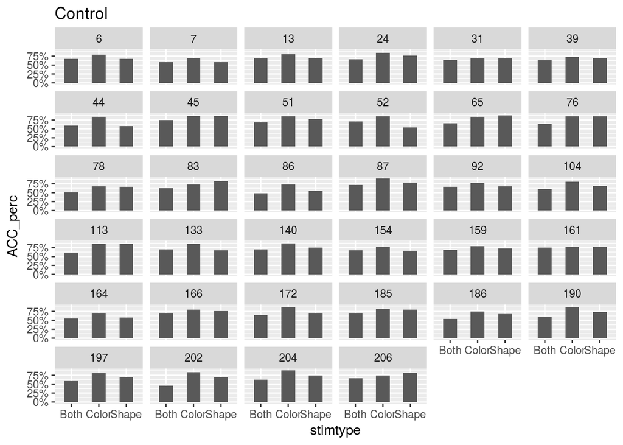

```r
#Control Group Data
VSTM_data_pre_control <- subset(VSTM_data_pre, group=="Control")
#change binary data to a percent
VSTM_data_pre_control_percent <- ddply(VSTM_data_pre_control, .(stimtype, subject), summarize, ACC_perc = mean(ACC))

#Experimental Group Data
VSTM_data_pre_experimental <- subset(VSTM_data_pre, group=="Experimental")
#change binary data to a percent
VSTM_data_pre_experimental_percent <- ddply(VSTM_data_pre_experimental, .(stimtype, subject), summarize, ACC_perc = mean(ACC))

ggplot(data = VSTM_data_pre_control_percent, aes( x = stimtype, y = ACC_perc)) + geom_bar(stat = "identity", width = 0.5) + facet_wrap(~subject) + scale_y_continuous(labels=percent) + scale_x_discrete(labels=c("Both","Color","Shape")) + ggtitle("Control")
```

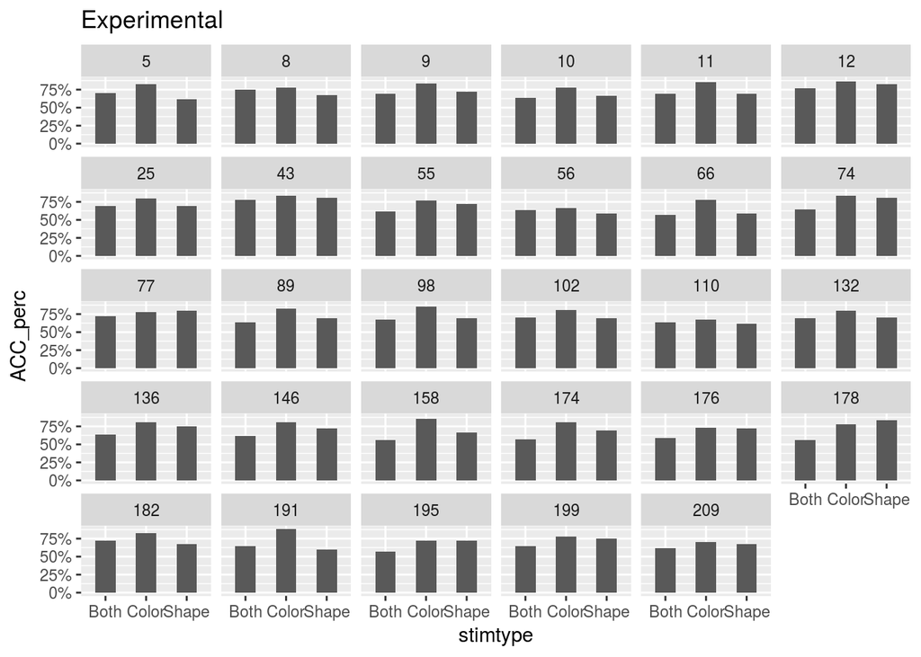

```r
ggplot(data = VSTM_data_pre_experimental_percent, aes( x = stimtype, y = ACC_perc)) + geom_bar(stat = "identity", width = 0.5) + facet_wrap(~subject) + scale_y_continuous(labels=percent) +  scale_x_discrete(labels=c("Both","Color","Shape")) + ggtitle("Experimental")
```

**Conclusion**: Subjects appear to be less accurate when trying to match both shape and color as opposed to either shape or color. No worrying data points.

### Model Accuracy (Logit)

```r
VSTM_ACC_model<-glmer(ACC ~ group*stimtype + (1|subject), family=binomial, data=VSTM_data_pre, verbose=TRUE)
```

[output not shown]

```r
summary(VSTM_ACC_model)
```

```
## Generalized linear mixed model fit by maximum likelihood (Laplace
##   Approximation) [glmerMod]
##  Family: binomial  ( logit )
## Formula: ACC ~ group * stimtype + (1 | subject)
##    Data: VSTM_data_pre
##
##      AIC      BIC   logLik deviance df.resid
##  14961.2  15013.4  -7473.6  14947.2    12838
##
## Scaled residuals:
##     Min      1Q  Median      3Q     Max
## -2.4289 -1.2808  0.5286  0.6737  0.9163
##
## Random effects:
##  Groups  Name        Variance Std.Dev.
##  subject (Intercept) 0.04175  0.2043
## Number of obs: 12845, groups:  subject, 63
##
## Fixed effects:
##                                     Estimate Std. Error z value Pr(>|z|)
## (Intercept)                          0.58440    0.05593  10.449  < 2e-16
## groupExperimental                    0.05764    0.08265   0.697    0.486
## stimtypeSimColour                    0.83650    0.06822  12.262  < 2e-16
## stimtypeSimShape                     0.36691    0.06371   5.759 8.45e-09
## groupExperimental:stimtypeSimColour -0.11227    0.10020  -1.120    0.263
## groupExperimental:stimtypeSimShape  -0.13865    0.09362  -1.481    0.139
##
## (Intercept)                         ***
## groupExperimental
## stimtypeSimColour                   ***
## stimtypeSimShape                    ***
## groupExperimental:stimtypeSimColour
## groupExperimental:stimtypeSimShape
## ---
## Signif. codes:  0 '***' 0.001 '**' 0.01 '*' 0.05 '.' 0.1 ' ' 1
##
## Correlation of Fixed Effects:
##             (Intr) grpExp stmtSC stmtSS grE:SC
## grpExprmntl -0.676
## stmtypSmClr -0.496  0.336
## stmtypSmShp -0.532  0.360  0.437
## grpExprm:SC  0.338 -0.502 -0.680 -0.297
## grpExprm:SS  0.362 -0.537 -0.297 -0.680  0.443
```

**Conclusion**: there is no group effect (as expected), participants are more accurate when they only have to guess if they saw one attribute (color or shape) versus both (color & shape) (as expected)

## **VSTM Reaction Time Analysis**

### Format RT data

(subset for RTs when they are accurate, greater than 200ms, and less than 5000 ms) (speed not important in this analysis) See how many observations are lost when we subset the data

```r
#all observations
print("All Data")
```

```
## [1] "All Data"
```

```r
All_data <- length(VSTM_data_pre$RT)
summary(VSTM_data_pre)
```

```
##     subject      session            group           stimtype
##  5      :  204   1:12845   Control     :6936   SimBoth  :4277
##  6      :  204             Experimental:5909   SimColour:4284
##  7      :  204                                 SimShape :4284
##  8      :  204
##  9      :  204
##  10     :  204
##  (Other):11621
##       ACC               RT
##  Min.   :0.0000   Min.   :    0
##  1st Qu.:0.0000   1st Qu.: 1034
##  Median :1.0000   Median : 1303
##  Mean   :0.7194   Mean   : 1508
##  3rd Qu.:1.0000   3rd Qu.: 1698
##  Max.   :1.0000   Max.   :27493
##
```

```r
#remove innacurate responses
print("Removed innacurate trials (from all data dataframe)")
```

```
## [1] "Removed innacurate trials (from all data dataframe)"
```

```r
VSTM_data_pre_RT <- subset(VSTM_data_pre, ACC==1)
All_acc_data <- length(VSTM_data_pre_RT$RT)
summary(VSTM_data_pre_RT)
```

```
##     subject     session           group           stimtype         ACC
##  45     : 169   1:9241   Control     :5001   SimBoth  :2766   Min.   :1
##  12     : 167            Experimental:4240   SimColour:3425   1st Qu.:1
##  43     : 165                                SimShape :3050   Median :1
##  87     : 163                                                 Mean   :1
##  65     : 162                                                 3rd Qu.:1
##  76     : 160                                                 Max.   :1
##  (Other):8255
##        RT
##  Min.   :  164
##  1st Qu.: 1015
##  Median : 1270
##  Mean   : 1441
##  3rd Qu.: 1626
##  Max.   :27493
##
```

```r
#remove short and long RTs
print("Removed slow and fast RTs")
```

```
## [1] "Removed slow and fast RTs"
```

```r
VSTM_data_pre_RT <- subset(VSTM_data_pre_RT, RT>200 & RT<5000)
filtered_data <- length(VSTM_data_pre_RT$RT)
summary(VSTM_data_pre_RT)
```

```
##     subject     session           group           stimtype         ACC
##  45     : 168   1:9190   Control     :4965   SimBoth  :2749   Min.   :1
##  12     : 167            Experimental:4225   SimColour:3415   1st Qu.:1
##  43     : 165                                SimShape :3026   Median :1
##  87     : 163                                                 Mean   :1
##  65     : 161                                                 3rd Qu.:1
##  76     : 160                                                 Max.   :1
##  (Other):8206
##        RT
##  Min.   : 206
##  1st Qu.:1014
##  Median :1268
##  Mean   :1408
##  3rd Qu.:1615
##  Max.   :4995
##
```

```r
print("Percentage of Data Removed")
```

```
## [1] "Percentage of Data Removed"
```

```r
perc_data_rm <- (1 - (filtered_data/All_acc_data) ) * 100
perc_data_rm
```

```
## [1] 0.5518883
```

**Conclusion**: Only half a percentage point of data removed, well within acceptable standards

### Graph RT data

Note: Only looking at RT data by condition.

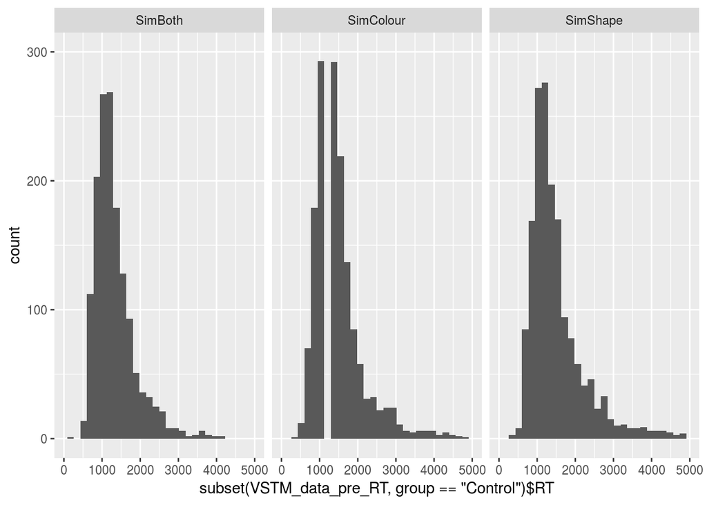

```r
#hist(subset(VSTM_data_pre_RT, group=="Control")$RT,ylim=c(0,1600))
#hist(subset(VSTM_data_pre_RT, group=="Experimental")$RT,ylim=c(0,1600))
ggplot(data = subset(VSTM_data_pre_RT, group=="Control"), aes(subset(VSTM_data_pre_RT, group=="Control")$RT)) + geom_histogram() + facet_wrap(~subset(VSTM_data_pre_RT, group=="Control")$stimtype) + scale_y_continuous(limits = c(0,300)) + scale_x_continuous(limits = c(0,5000))
```

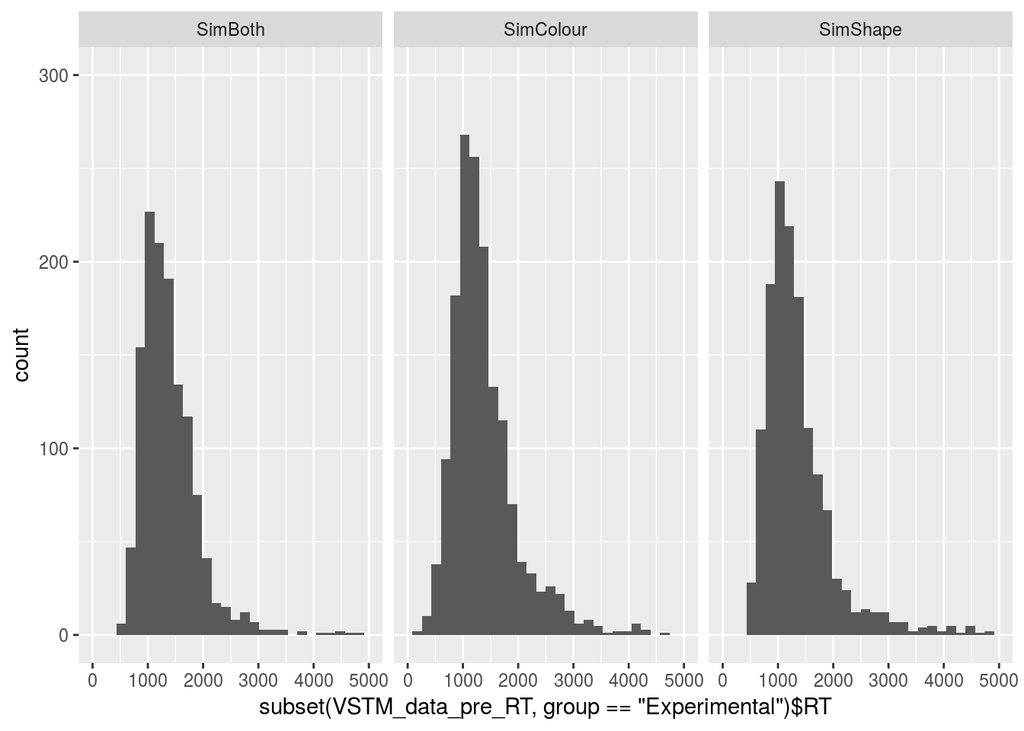

```r
ggplot(data = subset(VSTM_data_pre_RT, group=="Experimental"), aes(subset(VSTM_data_pre_RT, group=="Experimental")$RT)) + geom_histogram() + facet_wrap(~subset(VSTM_data_pre_RT, group=="Experimental")$stimtype) + scale_y_continuous(limits = c(0,300)) + scale_x_continuous(limits = c(0,5000))
```

**Conclusion**: This data shows some right skew (outliers to the right), trying log transform.

### Log Transform RT data

```r
VSTM_data_pre_RT$log_RT <- log(1/VSTM_data_pre_RT$RT)
```

### Graph logged RT data

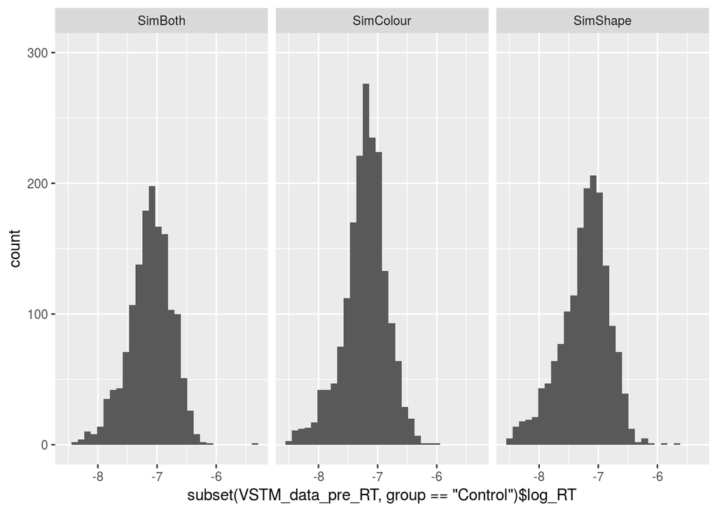

```r
#hist(subset(VSTM_data_pre_RT, group=="Control")$RT,ylim=c(0,1600))
#hist(subset(VSTM_data_pre_RT, group=="Experimental")$RT,ylim=c(0,1600))
ggplot(data = subset(VSTM_data_pre_RT, group=="Control"), aes(subset(VSTM_data_pre_RT, group=="Control")$log_RT)) + geom_histogram() + facet_wrap(~subset(VSTM_data_pre_RT, group=="Control")$stimtype) + scale_y_continuous(limits = c(0,300))
```

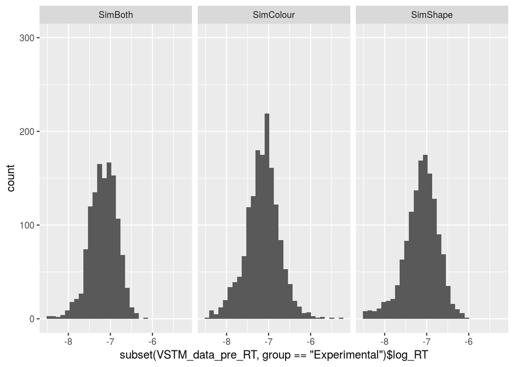

```r
ggplot(data = subset(VSTM_data_pre_RT, group=="Experimental"), aes(subset(VSTM_data_pre_RT, group=="Experimental")$log_RT)) + geom_histogram() + facet_wrap(~subset(VSTM_data_pre_RT, group=="Experimental")$stimtype) + scale_y_continuous(limits = c(0,300))
```

**Conclusion**: Data Appears to benefit from transform, using log RT for analysis

### Model log RT

```r
VSTM_RT_model <- lmer(log_RT ~ group*stimtype + (1|subject), data = VSTM_data_pre_RT)
summary(VSTM_RT_model)
```

```
## Linear mixed model fit by REML t-tests use Satterthwaite approximations
##   to degrees of freedom [lmerMod]
## Formula: log_RT ~ group * stimtype + (1 | subject)
##    Data: VSTM_data_pre_RT
##
## REML criterion at convergence: 6010.5
##
## Scaled residuals:
##     Min      1Q  Median      3Q     Max
## -4.7065 -0.5456  0.1080  0.6622  4.7593
##
## Random effects:
##  Groups   Name        Variance Std.Dev.
##  subject  (Intercept) 0.0373   0.1931
##  Residual             0.1092   0.3305
## Number of obs: 9190, groups:  subject, 63
##
## Fixed effects:
##                                       Estimate Std. Error         df
## (Intercept)                         -7.198e+00  3.423e-02  6.700e+01
## groupExperimental                    5.076e-02  5.044e-02  6.700e+01
## stimtypeSimColour                    6.420e-02  1.156e-02  9.124e+03
## stimtypeSimShape                    -5.116e-02  1.187e-02  9.124e+03
## groupExperimental:stimtypeSimColour -1.603e-02  1.700e-02  9.124e+03
## groupExperimental:stimtypeSimShape   4.108e-03  1.749e-02  9.124e+03
##                                      t value Pr(>|t|)
## (Intercept)                         -210.290  < 2e-16 ***
## groupExperimental                      1.007    0.318
## stimtypeSimColour                      5.554 2.87e-08 ***
## stimtypeSimShape                      -4.309 1.66e-05 ***
## groupExperimental:stimtypeSimColour   -0.943    0.346
## groupExperimental:stimtypeSimShape     0.235    0.814
## ---
## Signif. codes:  0 '***' 0.001 '**' 0.01 '*' 0.05 '.' 0.1 ' ' 1
##
## Correlation of Fixed Effects:
##             (Intr) grpExp stmtSC stmtSS grE:SC
## grpExprmntl -0.679
## stmtypSmClr -0.188  0.128
## stmtypSmShp -0.183  0.124  0.542
## grpExprm:SC  0.128 -0.187 -0.680 -0.369
## grpExprm:SS  0.124 -0.181 -0.368 -0.679  0.538
```

## **Conclusions**

good: No overall group differences or group interactions.

bad: Nothing that I can find, data are in good order.